# Fuel Economy Regression Modeling

Carlos Pelayo

3/13/2020

# Introduction:

Data are from the website http://fueleconomy.gov This is a problem in modeling/prediction. The idea is this: Fuel efficiency from 2010 and 2011 passenger cars and light trucks is provied. Using data from 2010, find the best model to predict fuel effiency; fit the model using data from 2010, and evaluate model performance using 2011 data.

# Questions:

# 1. Is there evidence of an improvement in fuel efficiency from 2010 to 2011?

# 2. What variables are most significant predictors of fuel efficienty?

The most significant predictors of fuel efficiency are engine displacement at the drive type description.

# 3. Suggest ways in which fuel efficienty could be improved in future years.

A way to improve fuel efficiency in future years is to have a vehicle that has a front-two wheel. Using the ANOVA model, we discovered, that the factor with the largest positive signifcant effect is the type of drive the vehicle has. Anoter way to improve fuel efficiency is to decrease the engine displacement of the vehicle.

```r
data(FuelEconomy)
library(lattice)
```

## Plot shown in the text:

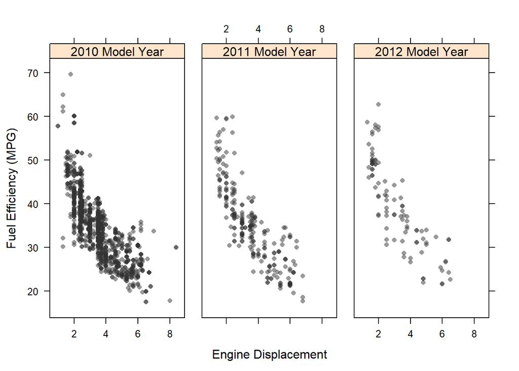

```r
cars2010 <- cars2010[order(cars2010$EngDispl),]
cars2011 <- cars2011[order(cars2011$EngDispl),]
cars2012 <- cars2012[order(cars2012$EngDispl),]
cars2010a <- cars2010
cars2010a$Year <- "2010 Model Year"
cars2011a <- cars2011
cars2011a$Year <- "2011 Model Year"
cars2012a <- cars2012
cars2012a$Year <- "2012 Model Year"

plotData <- rbind(cars2010a, cars2011a,cars2012a)
plotTheme <- bookTheme(TRUE)
plotTheme$plot.symbol$col <- rgb(.2, .2, .2, .5)
plotTheme$plot.symbol$cex <- 0.75
trellis.par.set(plotTheme)
xyplot(FE ~ EngDispl|Year, plotData,
xlab = "Engine Displacement",
ylab = "Fuel Efficiency (MPG)",
between = list(x = 1.2))
```

## difference in mean fuel efficiency 2010 to 2011 to 2012

$H_0$: no difference between FE in 2010 and 2011  
$H_A$: there is a difference in FE for years 2010 and 2011

We’ll use a t-test for this inference:

```r
t.test(cars2010a$FE, cars2011a$FE)
```

```
##
##  Welch Two Sample t-test
##
## data:  cars2010a$FE and cars2011a$FE
## t = -0.038381, df = 319.38, p-value = 0.9694
## alternative hypothesis: true difference in means is not equal to 0
## 95 percent confidence interval:
##  -1.263399  1.215049
## sample estimates:
## mean of x mean of y
##  34.70649  34.73066
```

```r
t.test(cars2010a$FE,cars2012a$FE)
```

```
##
##  Welch Two Sample t-test
##
## data:  cars2010a$FE and cars2012a$FE
## t = -4.6618, df = 102.9, p-value = 9.433e-06
## alternative hypothesis: true difference in means is not equal to 0
## 95 percent confidence interval:
##  -7.113664 -2.867408
## sample estimates:
## mean of x mean of y
##  34.70649  39.69703
```

```r
t.test(cars2011a$FE,cars2012a$FE)
```

```
##
##  Welch Two Sample t-test
##
## data:  cars2011a$FE and cars2012a$FE
## t = -4.137, df = 156.74, p-value = 5.724e-05
## alternative hypothesis: true difference in means is not equal to 0
## 95 percent confidence interval:
##  -7.337572 -2.595151
## sample estimates:
## mean of x mean of y
##  34.73066  39.69703
```

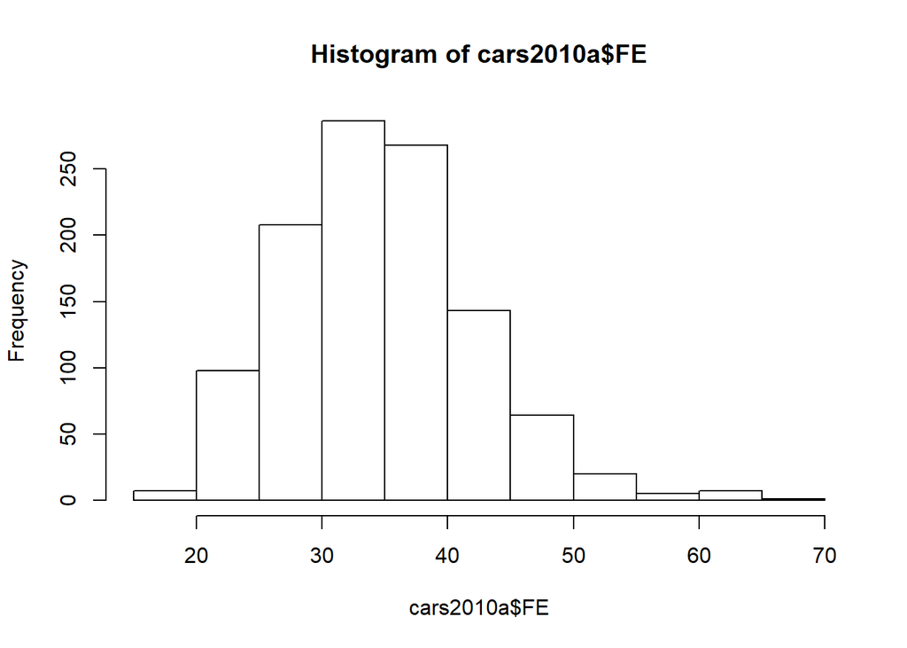

```r
hist(cars2010a$FE)
```

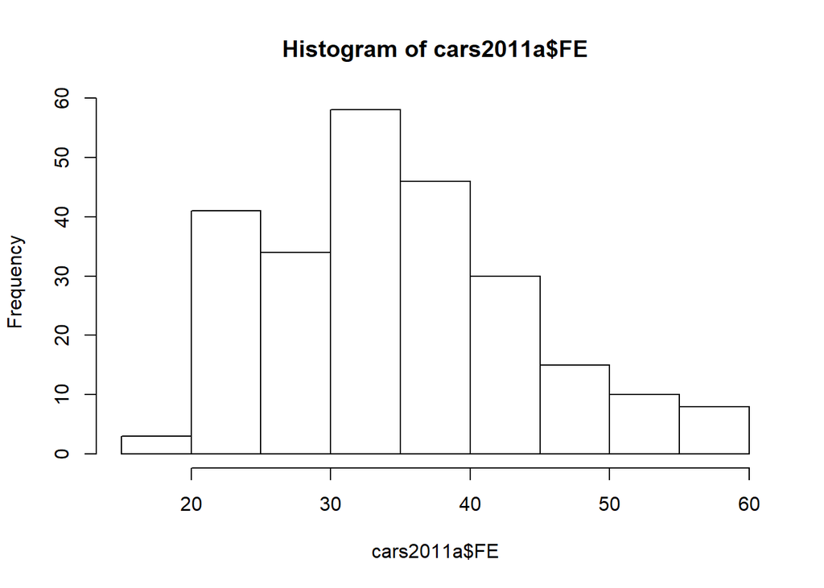

```r
hist(cars2011a$FE)
```

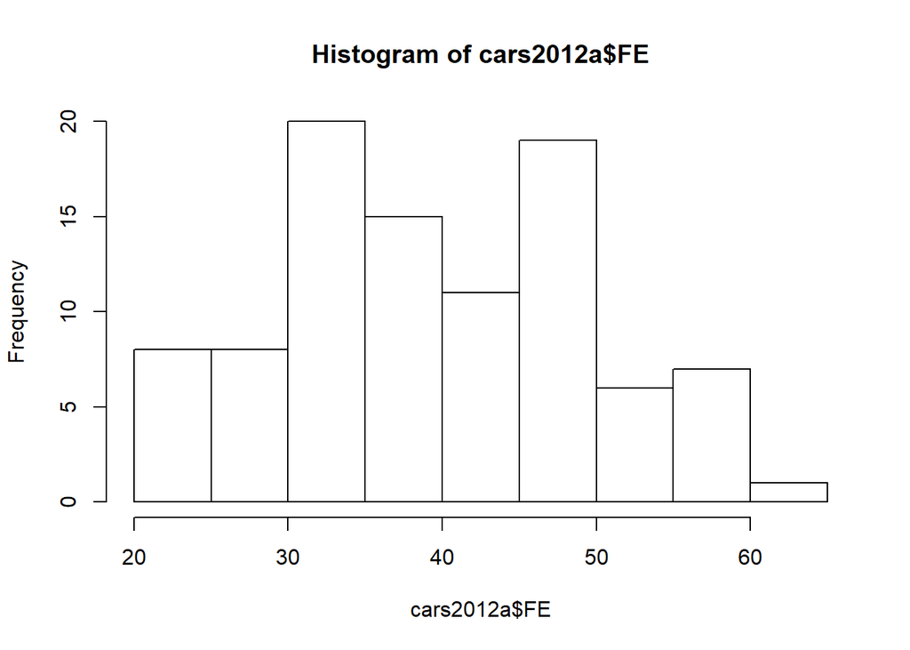

```r
hist(cars2012a$FE)
```

## difference in mean fuel efficiency 2010 to 2011

$H_0$: no difference between FE in 2010 and 2011 $H_A$: there is a difference in FE for years 2010 and 2011

Question #1:

### variables in the data set:

```r
names(cars2010a)
```

```
##  [1] "EngDispl"            "NumCyl"              "Transmission"
##  [4] "FE"                  "AirAspirationMethod" "NumGears"
##  [7] "TransLockup"         "TransCreeperGear"    "DriveDesc"
## [10] "IntakeValvePerCyl"   "ExhaustValvesPerCyl" "CarlineClassDesc"
## [13] "VarValveTiming"      "VarValveLift"        "Year"
```

## compare average fuel efficiency for 2011 cars using model1 to fuel efficiency for all cars in 2010

```r
model1 = glm(FE~ EngDispl, data=cars2010a)
summary(model1)
```

```
##
## Call:
## glm(formula = FE ~ EngDispl, data = cars2010a)
##
## Deviance Residuals:
##     Min       1Q   Median       3Q      Max
## -14.486   -3.192   -0.365    2.671   27.215
##
## Coefficients:
##             Estimate Std. Error t value Pr(>|t|)
## (Intercept)  50.5632     0.3985  126.89   <2e-16 ***
## EngDispl     -4.5209     0.1065  -42.46   <2e-16 ***
## ---
## Signif. codes:  0 '***' 0.001 '**' 0.01 '*' 0.05 '.' 0.1 ' ' 1
##
## (Dispersion parameter for gaussian family taken to be 21.38374)
##
##     Null deviance: 62180  on 1106  degrees of freedom
## Residual deviance: 23629  on 1105  degrees of freedom
## AIC: 6535.9
##
## Number of Fisher Scoring iterations: 2
```

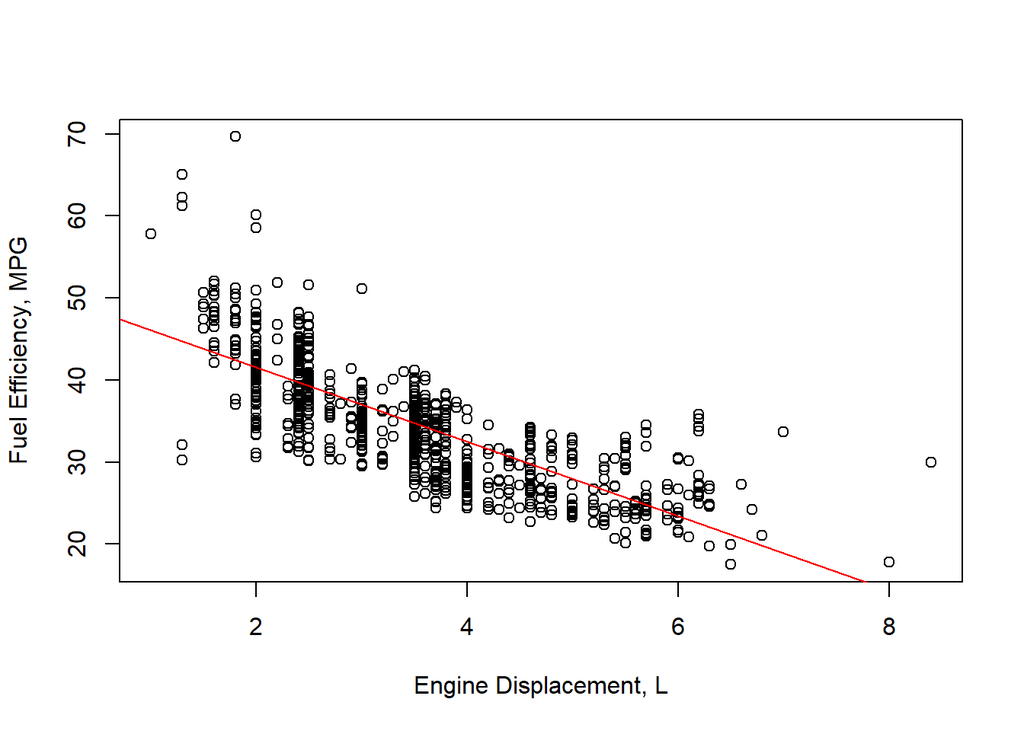

```r
plot(cars2010a$EngDispl, cars2010a$FE, xlab = 'Engine Displacement, L', ylab = 'Fuel Efficiency, MPG')
abline(model1, col='red')
```

### how does this fit model year 2011?

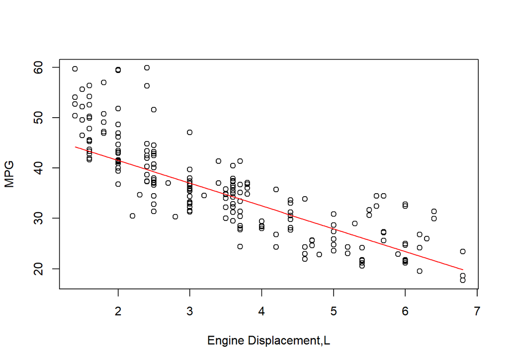

```r
plot(cars2011a$EngDispl, cars2011a$FE, xlab = 'Engine Displacement,L',ylab='MPG')
x = cars2011a$EngDispl
y = model1$coefficients[1] + model1$coefficients[2]*x
lines(x,y, col='red')
```

```r
model2 = glm(FE~ EngDispl + I(EngDispl^2), data = cars2010a)

summary(model2)
```

```
##
## Call:
## glm(formula = FE ~ EngDispl + I(EngDispl^2), data = cars2010a)
##
## Deviance Residuals:
##      Min        1Q    Median        3Q       Max
## -19.1862   -2.5977   -0.3028    2.6089   24.7385
##
## Coefficients:
##                Estimate Std. Error t value Pr(>|t|)
## (Intercept)    63.23343    0.94761   66.73   <2e-16 ***
## EngDispl      -11.86738    0.51627  -22.99   <2e-16 ***
## I(EngDispl^2)   0.93510    0.06453   14.49   <2e-16 ***
## ---
## Signif. codes:  0 '***' 0.001 '**' 0.01 '*' 0.05 '.' 0.1 ' ' 1
##
## (Dispersion parameter for gaussian family taken to be 17.98248)
##
##     Null deviance: 62180  on 1106  degrees of freedom
## Residual deviance: 19853  on 1104  degrees of freedom
## AIC: 6345.1
##
## Number of Fisher Scoring iterations: 2
```

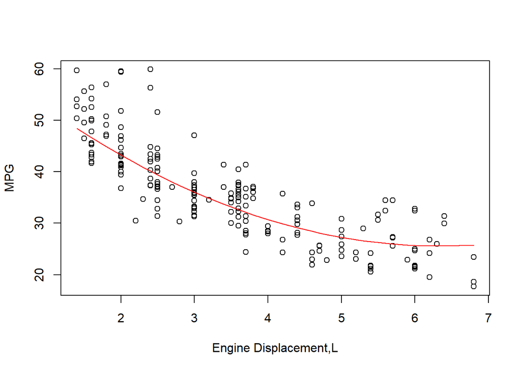

```r
w = cars2011a$EngDispl
z = model2$coefficients[1] + model2$coefficients[2]*x+model2$coefficients[3]*x^2
plot(cars2011a$EngDispl, cars2011a$FE, xlab = 'Engine Displacement,L',ylab='MPG')
lines(w,z, col='red')
```

### include transmission in the equation:

```r
levels(cars2010a$Transmission)
```

```
##  [1] "Other" "A4"    "A5"    "A6"    "A7"    "AM6"   "AM7"   "AV"    "AVS6"
## [10] "M5"    "M6"    "S4"    "S5"    "S6"    "S7"    "S8"
```

```r
model3 = glm(FE~ EngDispl+Transmission, data = cars2010a)
summary(model3)
```

```
##
## Call:
## glm(formula = FE ~ EngDispl + Transmission, data = cars2010a)
##
## Deviance Residuals:
##      Min        1Q    Median        3Q       Max
## -14.6654   -2.8212   -0.2927    2.6233   24.3152
##
## Coefficients:
##                  Estimate Std. Error t value Pr(>|t|)
## (Intercept)       56.1347     1.8701  30.017  < 2e-16 ***
## EngDispl          -4.3963     0.1145 -38.408  < 2e-16 ***
## TransmissionA4    -6.8996     1.8634  -3.703 0.000224 ***
## TransmissionA5    -7.2572     1.8738  -3.873 0.000114 ***
## TransmissionA6    -6.0856     1.8696  -3.255 0.001169 **
## TransmissionA7    -4.9828     1.9177  -2.598 0.009496 **
## TransmissionAM6  -10.4987     2.2703  -4.624 4.21e-06 ***
## TransmissionAM7   -9.2186     2.7183  -3.391 0.000720 ***
## TransmissionAV    -2.8962     1.9236  -1.506 0.132452
## TransmissionAVS6  -4.4500     2.2081  -2.015 0.044115 *
## TransmissionM5    -5.1567     1.8838  -2.737 0.006295 **
## TransmissionM6    -5.5541     1.8582  -2.989 0.002861 **
## TransmissionS4    -9.4991     2.2087  -4.301 1.85e-05 ***
## TransmissionS5    -7.0578     1.9371  -3.643 0.000282 ***
## TransmissionS6    -6.0485     1.8509  -3.268 0.001118 **
## TransmissionS7    -7.4846     2.0602  -3.633 0.000293 ***
## TransmissionS8    -3.1379     2.2735  -1.380 0.167808
## ---
## Signif. codes:  0 '***' 0.001 '**' 0.01 '*' 0.05 '.' 0.1 ' ' 1
##
## (Dispersion parameter for gaussian family taken to be 19.99269)
##
##     Null deviance: 62180  on 1106  degrees of freedom
## Residual deviance: 21792  on 1090  degrees of freedom
## AIC: 6476.3
##
## Number of Fisher Scoring iterations: 2
```

### predictions

```r
plot(cars2011a$EngDispl, cars2011a$FE, ylab='MPG', xlab='Engine displacement, L')
newData = cars2011a
y = predict(model3, newdata = cars2011a)

lines(cars2011a$EngDispl,y, col='grey')

#fit a smooth line to y then plot
ySmooth= glm(y~cars2011a$EngDispl)
summary(ySmooth)
```

```
##
## Call:
## glm(formula = y ~ cars2011a$EngDispl)
##
## Deviance Residuals:
##     Min       1Q   Median       3Q      Max
## -4.8355  -0.7107   0.0021   0.3858   5.8569
##
## Coefficients:
##                    Estimate Std. Error t value Pr(>|t|)
## (Intercept)        50.69283    0.25199  201.17   <2e-16 ***
## cars2011a$EngDispl -4.53463    0.06427  -70.56   <2e-16 ***
## ---
## Signif. codes:  0 '***' 0.001 '**' 0.01 '*' 0.05 '.' 0.1 ' ' 1
##
## (Dispersion parameter for gaussian family taken to be 2.181924)
##
##     Null deviance: 11391.97  on 244  degrees of freedom
## Residual deviance:   530.21  on 243  degrees of freedom
## AIC: 890.42
##
## Number of Fisher Scoring iterations: 2
```

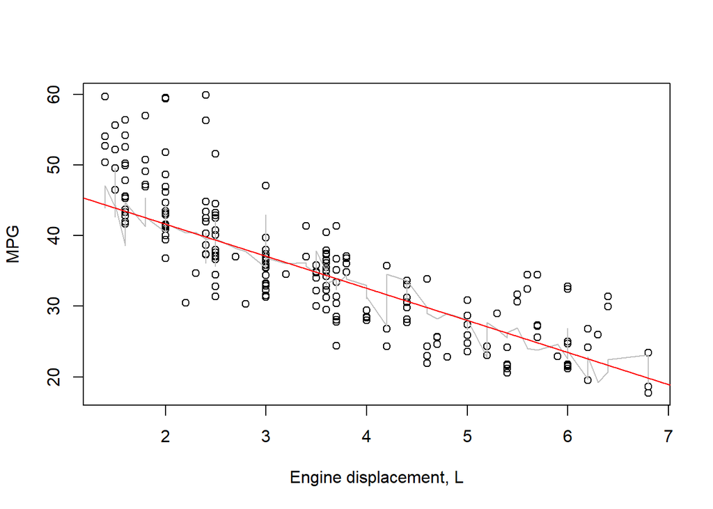

```r
abline(ySmooth, col='red')
```

Transmission effects ??

```r
model3AOV = aov(cars2010a$FE~cars2010a$Transmission)
summary(model3AOV)
```

```
##                          Df Sum Sq Mean Sq F value Pr(>F)
## cars2010a$Transmission   15  10894   726.3   15.45 <2e-16 ***
## Residuals              1091  51285    47.0
## ---
## Signif. codes:  0 '***' 0.001 '**' 0.01 '*' 0.05 '.' 0.1 ' ' 1
```

```r
TukeyHSD(model3AOV)
```

```
##   Tukey multiple comparisons of means
##     95% family-wise confidence level
##
## Fit: aov(formula = cars2010a$FE ~ cars2010a$Transmission)
##
## $`cars2010a$Transmission`
##                    diff          lwr         upr     p adj
## A4-Other    -6.24634755 -16.05822809  3.56553298 0.7068861
## A5-Other    -9.54401316 -19.40602078  0.31799446 0.0702783
## A6-Other    -8.70940000 -18.54789863  1.12909863 0.1541722
## A7-Other    -8.13097119 -18.22019622  1.95825385 0.2895103
## AM6-Other  -13.15648182 -25.10613372 -1.20682991 0.0153891
## AM7-Other  -18.49478000 -32.75211902 -4.23744098 0.0010094
## AV-Other    -0.30239273 -10.42542704  9.82064159 1.0000000
## AVS6-Other  -1.55863077 -13.17932999 10.06206846 1.0000000
## M5-Other     0.11233762  -9.78135328 10.00602853 1.0000000
## M6-Other    -4.35766347 -14.14111173  5.42578478 0.9789926
## S4-Other    -5.99896154 -17.61966076  5.62173769 0.9255777
## S5-Other    -4.69480000 -14.89017954  5.50057954 0.9715091
## S6-Other    -6.02267277 -15.76941301  3.72406747 0.7506809
## S7-Other    -9.82265455 -20.66678695  1.02147786 0.1282803
## S8-Other    -8.47342727 -20.42307918  3.47622463 0.5212300
## A5-A4       -3.29766561  -6.25396816 -0.34136305 0.0128270
## A6-A4       -2.46305245  -5.33995804  0.41385314 0.1971515
## A7-A4       -1.88462363  -5.52783545  1.75858818 0.9243740
## AM6-A4      -6.91013427 -14.27727151  0.45700298 0.0946899
## AM7-A4     -12.24843245 -22.96067995 -1.53618495 0.0089464
## AV-A4        5.94395483   2.20813439  9.67977526 0.0000068
## AVS6-A4      4.68771678  -2.13292696 11.50836052 0.5782847
## M5-A4        6.35868518   3.29835018  9.41902018 0.0000000
## M6-A4        1.88868408  -0.79392478  4.57129294 0.5344125
## S4-A4        0.24738601  -6.57325773  7.06802975 1.0000000
## S5-A4        1.55154755  -2.37608461  5.47917972 0.9935665
## S6-A4        0.22367478  -2.32180669  2.76915625 1.0000000
## S7-A4       -3.57630699  -8.96849932  1.81588534 0.6405693
## S8-A4       -2.22707972  -9.59421697  5.14005753 0.9996888
## A6-A5        0.83461316  -2.20886847  3.87809478 0.9999069
## A7-A5        1.41304197  -2.36309189  5.18917583 0.9963741
## AM6-A5      -3.61246866 -11.04623660  3.82129928 0.9544354
## AM7-A5      -8.95076684 -19.70894704  1.80741336 0.2386933
```

[output cut: 72 more lines]

```
## S4-M6       -1.64129807  -8.42097661  5.13838048 0.9999813
## S5-M6       -0.33713653  -4.19319079  3.51891774 1.0000000
## S6-M6       -1.66500930  -4.09859431  0.76857572 0.5863927
## S7-M6       -5.46499107 -10.80527180 -0.12471034 0.0386418
## S8-M6       -4.11576380 -11.44499100  3.21346340 0.8624293
## S5-S4        1.30416154  -6.05749217  8.66581524 0.9999997
## S6-S4       -0.02371123  -6.75030969  6.70288722 1.0000000
## S7-S4       -3.82369301 -12.06040285  4.41301683 0.9693674
## S8-S4       -2.47446573 -12.12031262  7.17138115 0.9999603
## S6-S5       -1.32787277  -5.08981909  2.43407355 0.9980932
## S7-S5       -5.12785455 -11.18990885  0.93419976 0.2141336
## S8-S5       -3.77862727 -11.64929913  4.09204458 0.9589067
## S7-S6       -3.79998178  -9.07271199  1.47274844 0.4911126
## S8-S6       -2.45075450  -9.73090951  4.82940051 0.9988874
## S8-S7        1.34922727  -7.34542161 10.04387615 1.0000000
```

## ANOVA

```r
modelAnova = glm(FE~EngDispl+
              NumCyl + Transmission+ AirAspirationMethod + NumGears+ TransLockup +TransCreeperGear + DriveDesc+ ExhaustValvesPerCyl+ VarValveTiming + VarValveLift,data=cars2010a)
summary(modelAnova)
```

```
##
## Call:
## glm(formula = FE ~ EngDispl + NumCyl + Transmission + AirAspirationMethod +
##     NumGears + TransLockup + TransCreeperGear + DriveDesc + ExhaustValvesPerCyl +
##     VarValveTiming + VarValveLift, data = cars2010a)
##
## Deviance Residuals:
##      Min        1Q    Median        3Q       Max
## -16.0640   -2.4276    0.1008    1.9872   22.8173
##
## Coefficients:
##                                 Estimate Std. Error t value Pr(>|t|)
## (Intercept)                      59.3326     2.5386  23.372  < 2e-16 ***
## EngDispl                         -2.9090     0.2596 -11.206  < 2e-16 ***
## NumCyl                           -0.6456     0.1623  -3.978 7.41e-05 ***
## TransmissionA4                   -8.5588     1.6058  -5.330 1.20e-07 ***
## TransmissionA5                   -7.7171     1.6326  -4.727 2.58e-06 ***
## TransmissionA6                   -6.1813     1.7496  -3.533 0.000428 ***
## TransmissionA7                   -3.3581     1.9783  -1.698 0.089886 .
## TransmissionAM6                  -7.8706     2.0305  -3.876 0.000113 ***
## TransmissionAM7                  -7.7413     2.5304  -3.059 0.002274 **
## TransmissionAV                   -7.0770     2.0886  -3.388 0.000728 ***
## TransmissionAVS6                 -9.4575     2.3142  -4.087 4.70e-05 ***
## TransmissionM5                   -7.3074     1.6336  -4.473 8.53e-06 ***
## TransmissionM6                   -6.1731     1.7236  -3.581 0.000357 ***
## TransmissionS4                  -10.5095     1.9089  -5.506 4.60e-08 ***
## TransmissionS5                   -7.6716     1.6888  -4.543 6.18e-06 ***
## TransmissionS6                   -4.9809     1.7218  -2.893 0.003894 **
## TransmissionS7                   -5.3388     2.0655  -2.585 0.009875 **
## TransmissionS8                   -0.3581     2.4547  -0.146 0.884024
## AirAspirationMethodSupercharged  -0.3095     0.9163  -0.338 0.735630
## AirAspirationMethodTurbocharged  -0.3188     0.3615  -0.882 0.378050
## NumGears                         -0.6180     0.4106  -1.505 0.132578
## TransLockup                      -1.1365     0.4136  -2.748 0.006101 **
## TransCreeperGear                 -0.7728     0.5669  -1.363 0.173084
## DriveDescFourWheelDrive          -0.8677     0.4398  -1.973 0.048730 *
## DriveDescParttimeFourWheelDrive  -1.9126     1.1924  -1.604 0.109009
## DriveDescTwoWheelDriveFront       5.8114     0.3729  15.583  < 2e-16 ***
## DriveDescTwoWheelDriveRear        1.8856     0.3652   5.163 2.89e-07 ***
## ExhaustValvesPerCyl              -1.7125     0.4148  -4.129 3.93e-05 ***
## VarValveTiming                    0.6177     0.3323   1.859 0.063330 .
## VarValveLift                      1.2749     0.3361   3.793 0.000157 ***
## ---
## Signif. codes:  0 '***' 0.001 '**' 0.01 '*' 0.05 '.' 0.1 ' ' 1
##
## (Dispersion parameter for gaussian family taken to be 14.083)
##
##     Null deviance: 62180  on 1106  degrees of freedom
## Residual deviance: 15167  on 1077  degrees of freedom
## AIC: 6101.1
##
## Number of Fisher Scoring iterations: 2
```

```r
anova(modelAnova)
```

```
## Analysis of Deviance Table
##
## Model: gaussian, link: identity
##
## Response: FE
##
## Terms added sequentially (first to last)
##
##
##                     Df Deviance Resid. Df Resid. Dev
## NULL                                 1106      62180
## EngDispl             1    38551      1105      23629
## NumCyl               1      247      1104      23382
## Transmission        15     1807      1089      21575
## AirAspirationMethod  2      117      1087      21459
## NumGears             1      104      1086      21355
## TransLockup          1      232      1085      21123
## TransCreeperGear     1       99      1084      21024
## DriveDesc            4     5401      1080      15623
## ExhaustValvesPerCyl  1      208      1079      15415
## VarValveTiming       1       45      1078      15370
## VarValveLift         1      203      1077      15167
```

```r
modelAnova2 = glm(FE~EngDispl+NumCyl+Transmission+TransLockup +DriveDesc+ ExhaustValvesPerCyl+VarValveLift,data=cars2010a)
summary(modelAnova2)
```

```
##
## Call:
## glm(formula = FE ~ EngDispl + NumCyl + Transmission + TransLockup +
##     DriveDesc + ExhaustValvesPerCyl + VarValveLift, data = cars2010a)
##
## Deviance Residuals:
##      Min        1Q    Median        3Q       Max
## -15.9498   -2.3436    0.0847    2.0701   22.9477
##
## Coefficients:
##                                 Estimate Std. Error t value Pr(>|t|)
## (Intercept)                      56.7055     1.8720  30.291  < 2e-16 ***
## EngDispl                         -2.8244     0.2491 -11.336  < 2e-16 ***
## NumCyl                           -0.6726     0.1593  -4.223 2.62e-05 ***
## TransmissionA4                   -8.6629     1.6006  -5.412 7.67e-08 ***
## TransmissionA5                   -8.4269     1.6036  -5.255 1.78e-07 ***
## TransmissionA6                   -7.5705     1.5986  -4.736 2.47e-06 ***
## TransmissionA7                   -5.1454     1.6425  -3.133  0.00178 **
## TransmissionAM6                  -9.0455     1.9150  -4.723 2.62e-06 ***
## TransmissionAM7                  -9.4304     2.3075  -4.087 4.70e-05 ***
## TransmissionAV                   -5.1643     1.6373  -3.154  0.00165 **
## TransmissionAVS6                 -7.4780     1.8756  -3.987 7.14e-05 ***
## TransmissionM5                   -7.8883     1.6125  -4.892 1.15e-06 ***
## TransmissionM6                   -7.4276     1.5805  -4.699 2.94e-06 ***
## TransmissionS4                  -10.9187     1.8935  -5.767 1.06e-08 ***
## TransmissionS5                   -8.4310     1.6559  -5.092 4.18e-07 ***
## TransmissionS6                   -6.2924     1.5693  -4.010 6.50e-05 ***
## TransmissionS7                   -7.1496     1.7464  -4.094 4.56e-05 ***
## TransmissionS8                   -2.8752     1.9297  -1.490  0.13653
## TransLockup                      -1.0570     0.4104  -2.575  0.01015 *
## DriveDescFourWheelDrive          -0.9261     0.4330  -2.139  0.03268 *
## DriveDescParttimeFourWheelDrive  -1.7480     1.1905  -1.468  0.14232
## DriveDescTwoWheelDriveFront       5.9419     0.3647  16.293  < 2e-16 ***
## DriveDescTwoWheelDriveRear        1.8889     0.3615   5.225 2.09e-07 ***
## ExhaustValvesPerCyl              -1.5079     0.4027  -3.745  0.00019 ***
## VarValveLift                      1.3838     0.3299   4.194 2.96e-05 ***
## ---
## Signif. codes:  0 '***' 0.001 '**' 0.01 '*' 0.05 '.' 0.1 ' ' 1
##
## (Dispersion parameter for gaussian family taken to be 14.14553)
##
##     Null deviance: 62180  on 1106  degrees of freedom
## Residual deviance: 15305  on 1082  degrees of freedom
## AIC: 6101.1
##
## Number of Fisher Scoring iterations: 2
```

```r
anova(modelAnova2)
```

```
## Analysis of Deviance Table
##
## Model: gaussian, link: identity
##
## Response: FE
##
## Terms added sequentially (first to last)
##
##
##                     Df Deviance Resid. Df Resid. Dev
## NULL                                 1106      62180
## EngDispl             1    38551      1105      23629
## NumCyl               1      247      1104      23382
## Transmission        15     1807      1089      21575
## TransLockup          1      174      1088      21402
## DriveDesc            4     5673      1084      15729
## ExhaustValvesPerCyl  1      174      1083      15554
## VarValveLift         1      249      1082      15305
```

```r
filtered2010=filter(cars2010a,DriveDesc== 'TwoWheelDriveFront'&  VarValveLift==1 & EngDispl>3)
modelAnovaFinal = glm(FE~EngDispl,data=filtered2010)
summary(modelAnovaFinal)
```

```
##
## Call:
## glm(formula = FE ~ EngDispl, data = filtered2010)
##
## Deviance Residuals:
##     Min       1Q   Median       3Q      Max
## -4.8968  -1.4254   0.0803   1.4619   4.3557
##
## Coefficients:
##             Estimate Std. Error t value Pr(>|t|)
## (Intercept)   80.298     15.609   5.144 0.000435 ***
## EngDispl     -12.415      4.361  -2.847 0.017335 *
## ---
## Signif. codes:  0 '***' 0.001 '**' 0.01 '*' 0.05 '.' 0.1 ' ' 1
##
## (Dispersion parameter for gaussian family taken to be 7.273151)
##
##     Null deviance: 131.690  on 11  degrees of freedom
## Residual deviance:  72.732  on 10  degrees of freedom
## AIC: 61.677
##
## Number of Fisher Scoring iterations: 2
```

```r
anova(modelAnovaFinal)
```

```
## Analysis of Deviance Table
##
## Model: gaussian, link: identity
##
## Response: FE
##
## Terms added sequentially (first to last)
##
##
##          Df Deviance Resid. Df Resid. Dev
## NULL                        11    131.690
## EngDispl  1   58.958        10     72.732
```

make a prediction for 2011

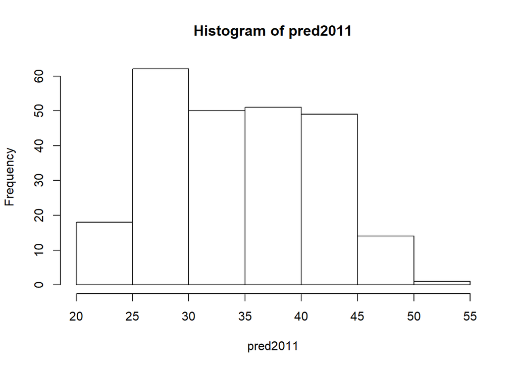

```r
pred2011 = predict(modelAnova2, cars2011a)
pred2011a=predict(modelAnovaFinal,cars2011a)
hist(pred2011)
```

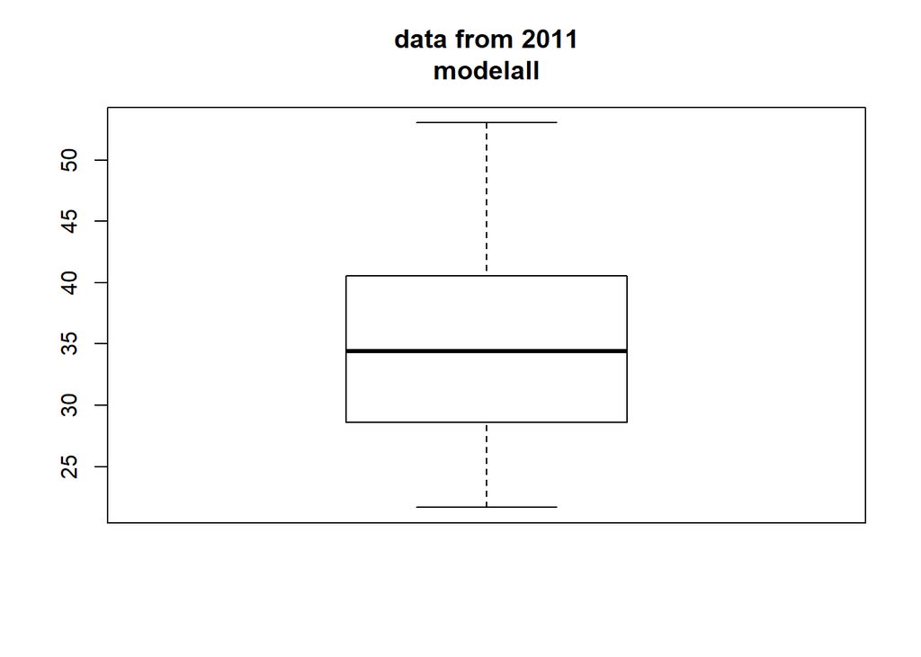

```r
boxplot(pred2011, main='data from 2011\nmodelall')
```

```r
t.test(cars2011a$FE, pred2011)
```

```
##
##  Welch Two Sample t-test
##
## data:  cars2011a$FE and pred2011
## t = 0.31738, df = 456.43, p-value = 0.7511
## alternative hypothesis: true difference in means is not equal to 0
## 95 percent confidence interval:
##  -1.219634  1.689460
## sample estimates:
## mean of x mean of y
##  34.73066  34.49575
```

###Average Efficiency

```r
print(mean(pred2011))
```

```
## [1] 34.49575
```

```r
print(mean(pred2011a))
```

```
## [1] 35.16187
```